# Data visualization and processing for Big Geospatial Data Class, group III, TU MUNCHEN

Marcel Siedlich

# 1 Libraries

The following libraries have been used for the data processing and exploratory visualizations:

- lubridate
- dplyr
- ggplot2
- kableExtra
- sf

```r
library(sf)
library(lubridate)
library(dplyr)
library(ggplot2)
library(kableExtra)
```

# 2 Data

Years 2016 - 2022 have been taken into account for the analysis.

## 2.1 Munich boundaries

The vector data layer featuring the boundaries of Munich (alongside with its districts) has been acquired from the classes that we had on TUM. It will be featured in the GitHub repository of our project. Only the layer boundaries were relevant during the analysis as they indicate the extent to which the point data containing the MVG bike trips should be cropped.

```r
#loading the data
#outside the boundaries of Munich


#setting working directory
setwd("C:/Users/marsi/Desktop/Szkoła/Munchen I/Big Data")

#Munich city extent
munich = st_read("districts_munich.shp")
```

## 2.2 Land use grid layer

The land use grid vector layer has been created based on the OSM data. Its creation process has been described in the final report of our project.

```r
#Grid load
grid = st_read("./Grid/GRID_REALLY_FINAL_VERSION.shp")
```

## 2.3 Weather data sets

The weather data in the form of csv tables has been acquired from the Deutscher Wetterdienst. Data sets for temperatures, precipitation for the station 3379 / München-Stadt cover many years even beyond our analysis period. The time stamp of each row is hourly, so the data sets covers years, months and days hour after hour.

Links for the following data can be found below:

- temperature https://opendata.dwd.de/climate_environment/CDC/observations_germany/climate/hourly/air_temperature/historical/stundenwerte_TU_03379_19970701_20221231_hist.zip
- precipitation https://opendata.dwd.de/climate_environment/CDC/observations_germany/climate/hourly/precipitation/historical/stundenwerte_RR_03379_19970707_20221231_hist.zip
- wind https://opendata.dwd.de/climate_environment/CDC/observations_germany/climate/hourly/wind/historical/stundenwerte_FF_03379_19850101_20221231_hist.zip

```r
#temperature data
temperature = read.table("./hourly_data/temperature.txt",sep=";",header=T)
temperature$MESS_DATUM = ymd_h(temperature$MESS_DATUM)

#precipitation
precipitation = read.table("./hourly_data/precipitation.txt",sep=";",header=T)
precipitation$MESS_DATUM = ymd_h(precipitation$MESS_DATUM)

#wind
wind = read.table("./hourly_data/wind.txt",sep=";",header=T)
wind$MESS_DATUM = ymd_h(wind$MESS_DATUM)
```

## 2.4 MVG bike trips data

The csv files featuring data with the starting and ending points of the MVG bike trips have been acquired from the MVG website.

https://www.mvg.de/services/mvg-rad.html

Please search for the “Raw data for download” tab.

```r
#loading the data
data_2016 = read.csv('MVG_Rad_Fahrten_2016.csv', TRUE, sep = ";", dec = "," )
data_2017 = read.csv('MVG_Rad_Fahrten_2017.csv', TRUE, sep = ";", dec = "," )
data_2018 = read.csv('MVG_Rad_Fahrten_2018.csv', TRUE, sep = ";", dec = "," )
data_2019 = read.csv('MVG_Rad_Fahrten_2019.csv', TRUE, sep = ";", dec = "," )
data_2020 = read.csv('MVG_Rad_Fahrten_2020.csv', TRUE, sep = ";", dec = "," )
data_2021 = read.csv('MVG_Rad_Fahrten_2021.csv', TRUE, sep = ";", dec = "," )
data_2022 = read.csv('MVG_Rad_Fahrten_2022.csv', TRUE, sep = ";", dec = "," )
```

# 3 Data Processing

## 3.1 Defining the function for data processing

A simple function has been written to unify the data for all years in a one batch. The function automatically crops the MVG point data set to the desired extent, joins the land use layer and processes the data for the further analyses.

```r
data_segmentation = function(data, grid, munich, temperature, precipitation, wind, desired_months){

  #spatial aspect. filtering by the start point within Munich
  data1 = st_as_sf(data, coords = c("STARTLON","STARTLAT"), crs = 4326)
  data1 = st_filter(data1, munich)

  #adding landuse info to start points
  landuse = select(grid,c(2,3,6))
  data1 = st_join(data1, landuse, join = st_intersects)
  colnames(data1)[colnames(data1) == 'type_1'] <- 'landuse_start'
  colnames(data1)[colnames(data1) == 'buildPOP'] <- 'buildPOP_start'

  #spatial aspect. filtering by the end point within Munich
  data2 = st_as_sf(data, coords = c("ENDLON","ENDLAT"), crs = 4326)
  data2 = st_filter(data2,munich)

  #adding landuse info to end points
  data2 = st_join(data2, landuse, join = st_intersects)
  colnames(data2)[colnames(data2) == 'type_1'] <- 'landuse_end'
  colnames(data2)[colnames(data2) == 'buildPOP'] <- 'buildPOP_end'


  #filtering off values and some tricks to futher process the data
  data = filter(data, Row %in% data1$Row)
  data = filter(data, Row %in% data2$Row)


  #adding landuse info to the final dataset
  data = inner_join(data, select(data1,c(1,10,11)), by = "Row")
  data = inner_join(data, select(data2,c(1,10,11)), by = "Row")

  data = select(data, !c(14,17))

  #duration of a trip
  data$Duration_minutes = as.numeric((ymd_hm(data$ENDTIME) - ymd_hm(data$STARTTIME))/60)




  #Duration filtering. Only trips with non-negative duration and up to 1 day are taken into account
  data = dplyr::filter(data, Duration_minutes > 0 & Duration_minutes <= 1440)

  #Some trips start and end exactly in the same coordinates. Cleaning these rows
  data = dplyr::filter(data, (STARTLON != ENDLON) & (STARTLAT != ENDLAT))


  #start and end date - It's just for day date without hour, you can activate it if you wish
  data$Date = as.Date(ymd_hm(data$STARTTIME))

  #time selection - I think it's unecessary, but leave it in case you want to use
  data$StartTime = format(ymd_hm(data$STARTTIME),"%H:%M")
  data$EndTime = format(ymd_hm(data$ENDTIME),"%H:%M")

  #month day, day of the month
  data$month_day = day(data$Date)

  #month selection
  data$Month = month(data$Date)

  #filter by desired months
  data = filter(data,Month %in% desired_months)

  #year info
  data$Year = year(data$Date)

  #week starts from Monday, week days will be numbers from 1 to 7
  data$Week_Day = wday(data$Date, FALSE, FALSE, 1)

  #travel start hour

  data$hour = hour(hm(data$StartTime))


  #weekday morning rush
  data$if_week_morning_rush = 1
  data$if_week_morning_rush [data$Week_Day == 6 | data$Week_Day == 7] = 0
  data$if_week_morning_rush [data$hour < 6 | data$hour > 9] = 0

  #weekday afternoon rush
  data$if_week_afternoon_rush = 1
  data$if_week_afternoon_rush [data$Week_Day == 6 | data$Week_Day == 7] = 0
  data$if_week_afternoon_rush [data$hour < 16 | data$hour > 18] = 0

  #weekday midday
  data$if_week_midday = 1
  data$if_week_midday [data$Week_Day == 6 | data$Week_Day == 7] = 0
  data$if_week_midday [data$hour <= 9 | data$hour >= 16] = 0

  #weekday evening
  data$if_week_evening = 1
  data$if_week_evening [data$Week_Day == 6 | data$Week_Day == 7] = 0
  data$if_week_evening [data$hour <= 18 | data$hour >= 22] = 0

  #weekday night
  data$if_week_night = 1
  data$if_week_night [data$Week_Day == 6 | data$Week_Day == 7] = 0
  data$if_week_night [data$hour %in% c(6:21)] = 0






  #weekend morning rush
  data$if_weekend_morning_rush = 0
  data$if_weekend_morning_rush [data$Week_Day == 6 | data$Week_Day == 7] = 1
  data$if_weekend_morning_rush [data$hour < 6 | data$hour > 9] = 0

  #weekend afternoon rush
  data$if_weekend_afternoon_rush = 0
  data$if_weekend_afternoon_rush [data$Week_Day == 6 | data$Week_Day == 7] = 1
  data$if_weekend_afternoon_rush [data$hour < 16 | data$hour > 18] = 0

  #weekend midday
  data$if_weekend_midday = 0
  data$if_weekend_midday [data$Week_Day == 6 | data$Week_Day == 7] = 1
  data$if_weekend_midday [data$hour <= 9 | data$hour >= 16] = 0

  #weekend evening
  data$if_weekend_evening = 0
  data$if_weekend_evening [data$Week_Day == 6 | data$Week_Day == 7] = 1
  data$if_weekend_evening [data$hour <= 18 | data$hour >= 22] = 0

  #weekend night
  data$if_weekend_night = 0
  data$if_weekend_night [data$Week_Day == 6 | data$Week_Day == 7] = 1
  data$if_weekend_night [data$hour %in% c(6:21)] = 0




  #hard lockdowns first

  lockdown = interval(ymd('2020-03-22'),ymd('2020-05-04'))

  data$first_lockdown = 0
  data$first_lockdown [data$Date %within% lockdown] = 1

  data$before_lockdown = 0
  data$before_lockdown [data$Date < ymd('2020-03-22')] = 1

  data$after_lockdown = 0
  data$after_lockdown [data$Date > ymd('2020-05-04')] = 1


  #temperature
  temperature$Date = as.Date(ymd_hms(temperature$MESS_DATUM))
  temperature = filter(temperature, year(MESS_DATUM) %in% data$Year)
  temperature$hour = hour(temperature$MESS_DATUM)

  #renaming columns
  colnames(temperature)[colnames(temperature) == 'TT_TU'] <- 'Air_Temperature'

  #formatting the table
  temperature = select(temperature, Date, hour, Air_Temperature)

  #if temperature data is extremely weird, then my own idea
  #if temperature is lower than -30 or higher than 45
  #(its mostly -999 then)
  #then, you find the next reliable temperature and set the -999 as it
  for(i in c(1:length(temperature$Air_Temperature))){
    if (temperature$Air_Temperature[i] < -30 | temperature$Air_Temperature[i] > 45){
      j = i

      controler = TRUE
      while(controler == TRUE){
        if(temperature$Air_Temperature[j] < -30 | temperature$Air_Temperature[j] > 45){
          j = j+1
        }else{
          temperature$Air_Temperature[i] = temperature$Air_Temperature[j]

          controler = FALSE
        }
      }
    }
  }


  #joining the data - temperature
  data = left_join(data, temperature, by = c("Date","hour"))


  #precipitation data cleaning
  precipitation$Date = as.Date(ymd_hms(precipitation$MESS_DATUM))
  precipitation = filter(precipitation, year(MESS_DATUM) %in% data$Year)
  precipitation$hour = hour(precipitation$MESS_DATUM)

  #renaming columns
  colnames(precipitation)[colnames(precipitation) == 'R1'] <- 'Precipitation_mm'

  #formatting the table
  precipitation = select(precipitation, Date, hour, Precipitation_mm)

  for(i in c(1:length(precipitation$Precipitation_mm))){
    if (precipitation$Precipitation_mm[i] < 0){
      j = i

      controler = TRUE
      while(controler == TRUE){
        if(precipitation$Precipitation_mm[j] < 0){
          j = j+1
        }else{
          precipitation$Precipitation_mm[i] = precipitation$Precipitation_mm[j]

          controler = FALSE
        }
      }
    }
  }

  #joining the data - precipitation
  data = left_join(data, precipitation, by = c("Date","hour"))

  #wind data
  wind$Date = as.Date(ymd_hms(wind$MESS_DATUM))
  wind = filter(wind, year(MESS_DATUM) %in% data$Year)
  wind$hour = hour(wind$MESS_DATUM)

  #renaming columns
  colnames(wind)[colnames(wind) == 'F'] <- 'Wind_velocity_ms'

  #formatting the table
  wind = select(wind, Date, hour, Wind_velocity_ms)

  #wind data is extremely weird, then my own idea
  #wind velocity is lower than -30 or higher than 45
  #(its mostly -999 then)
  #then, you find the next reliable temperature and set the -999 as it
  for(i in c(1:length(wind$Wind_velocity_ms))){
    if (wind$Wind_velocity_ms[i] < 0){
      j = i

      controler = TRUE
      while(controler == TRUE){
        if(wind$Wind_velocity_ms[j] < 0){
          j = j+1
        }else{
          wind$Wind_velocity_ms[i] = wind$Wind_velocity_ms[j]

          controler = FALSE
        }
      }
    }
  }

  #joining the data - wind
  data = left_join(data, wind, by = c("Date","hour"))


  return(data)
}
```

## 3.2 Calling the function for data processing

The earlier declared function has been called for all the csv layers from MVG. Then, all the years have been joined in a one big dataset.

```r
#months in numbers (like 1 for january etc)
#Input data cropped to Munich extent and with grid cells ids!
results_2016 = data_segmentation(data_2016, grid,munich, temperature, precipitation, wind,c(1:12))
#write.csv(results_2016, "data_2016.csv")

results_2017 = data_segmentation(data_2017, grid,munich, temperature, precipitation, wind,c(1:12))
#write.csv(results_2017, "data_2017.csv")

results_2018 = data_segmentation(data_2018, grid,munich, temperature, precipitation, wind,c(1:12))
#write.csv(results_2018, "data_2018.csv")

results_2019 = data_segmentation(data_2019, grid,munich, temperature, precipitation, wind,c(1:12))
#write.csv(results_2019, "data_2019.csv")

results_2020 = data_segmentation(data_2020, grid,munich, temperature, precipitation, wind,c(1:12))
#write.csv(results_2020, "data_2020.csv")

results_2021 = data_segmentation(data_2021, grid,munich, temperature, precipitation, wind,c(1:12))
#write.csv(results_2021, "data_2021.csv")

results_2022 = data_segmentation(data_2022, grid,munich, temperature, precipitation, wind,c(1:12))
#write.csv(results_2022, "data_2022.csv")

data_every_alot = rbind(results_2016,results_2017,results_2018,
                   results_2019,results_2020,results_2021,results_2022)


#data every selection of useful columns
data_every_use = select(data_every_alot, c(1,4:7,12:17,21,22,24:40))
```

## 3.3 Binary land use data representation

In order to build a model for our analysis, from-to MVG trips had to converted to a binary form. It means that for example if a trip starts in residential area and ends in industrial, then the value of the residential_start column will be 1 and the industrial_end column will be 1. Otherwise all other land use binary columns will be 0 for the specific row.

In addition, as R-based distance calculation functions have very slow performance, the start-end distance column has been calculated in Python and then joined back to the rest of data in R.

```r
#adding distances. Those had to be calculated separately in Python
#took way too much time in R
distances = read.csv('data_everything_wDist.csv', TRUE, sep = ";", dec = ".")


#that is the final dataset
data_every_use = cbind(data_every_use, select(distances,12))

#land use to 0 and 1

###RESIDENTIAL
unique(data_every_use$landuse_start)
```

```
## [1] "residential"  "mixed-use"    "recreational" "university"   "commercial"
## [6] "industrial"   "farmland"     NA
```

```r
data_every_use$residential_start = 0
data_every_use$residential_start[data_every_use$landuse_start == 'residential'] = 1

data_every_use$residential_end = 0
data_every_use$residential_end[data_every_use$landuse_end == 'residential'] = 1

###mixed-use
data_every_use$mixed_start = 0
data_every_use$mixed_start[data_every_use$landuse_start == 'mixed-use'] = 1

data_every_use$mixed_end = 0
data_every_use$mixed_end[data_every_use$landuse_end == 'mixed-use'] = 1

###recreational
data_every_use$recreational_start = 0
data_every_use$recreational_start[data_every_use$landuse_start == 'recreational'] = 1

data_every_use$recreational_end = 0
data_every_use$recreational_end[data_every_use$landuse_end == 'recreational'] = 1

###university
data_every_use$university_start = 0
data_every_use$university_start[data_every_use$landuse_start == 'university'] = 1

data_every_use$university_end = 0
data_every_use$university_end[data_every_use$landuse_end == 'university'] = 1

###commercial
data_every_use$commercial_start = 0
data_every_use$commercial_start[data_every_use$landuse_start == 'commercial'] = 1

data_every_use$commercial_end = 0
data_every_use$commercial_end[data_every_use$landuse_end == 'commercial'] = 1

###industrial
data_every_use$industrial_start = 0
data_every_use$industrial_start[data_every_use$landuse_start == 'industrial'] = 1

data_every_use$industrial_end = 0
data_every_use$industrial_end[data_every_use$landuse_end == 'industrial'] = 1

###farmland
data_every_use$farmland_start = 0
data_every_use$farmland_start[data_every_use$landuse_start == 'farmland'] = 1

data_every_use$farmland_end = 0
data_every_use$farmland_end[data_every_use$landuse_end == 'farmland'] = 1

#final export data

data_every_use_export = select(data_every_use, -c(6,8))
```

## 3.4 Sample header of the dataset

```r
head(data_every_use_export)
```

|  | Row | STARTLAT | STARTLON | ENDLAT | ENDLON | buildPOP_start | buildPOP_end | Duration_minutes | Date | Month | Year | hour | if_week_morning_rush | if_week_afternoon_rush | if_week_midday | if_week_evening | if_week_night | if_weekend_morning_rush | if_weekend_afternoon_rush | if_weekend_midday | if_weekend_evening | if_weekend_night | first_lockdown | before_lockdown | after_lockdown | Air_Temperature | Precipitation_mm | Wind_velocity_ms | distance | … |
| --- | --- | --- | --- | --- | --- | --- | --- | --- | --- | --- | --- | --- | --- | --- | --- | --- | --- | --- | --- | --- | --- | --- | --- | --- | --- | --- | --- | --- | --- | --- |
| 1 | 1 | 48.16955 | 11.56095 | 48.10944 | 11.47498 | 2259.4389 | 1130.2228 | 61 | 2016-01-01 | 1 | 2016 | 0 | 0 | 0 | 0 | 0 | 1 | 0 | 0 | 0 | 0 | 0 | 0 | 1 | 0 | 5.2 | 0.1 | 0.4 | 9.23953118 | … |
| 2 | 2 | 48.10083 | 11.5476 | 48.10021 | 11.54739 | 943.8175 | 943.8175 | 5 | 2016-01-01 | 1 | 2016 | 1 | 0 | 0 | 0 | 0 | 1 | 0 | 0 | 0 | 0 | 0 | 0 | 1 | 0 | 4.7 | 0.0 | 0.9 | 0.07068257 | … |
| 3 | 3 | 48.15999 | 11.58589 | 48.13621 | 11.56093 | 2256.4336 | 1320.7407 | 26 | 2016-01-01 | 1 | 2016 | 1 | 0 | 0 | 0 | 0 | 1 | 0 | 0 | 0 | 0 | 0 | 0 | 1 | 0 | 4.7 | 0.0 | 0.9 | 3.22815436 | … |
| 4 | 4 | 48.15483 | 11.56148 | 48.13126 | 11.5975 | 4048.0961 | 4104.3752 | 22 | 2016-01-01 | 1 | 2016 | 1 | 0 | 0 | 0 | 0 | 1 | 0 | 0 | 0 | 0 | 0 | 0 | 1 | 0 | 4.7 | 0.0 | 0.9 | 3.74321619 | … |
| 5 | 5 | 48.1304 | 11.57953 | 48.13683 | 11.58971 | 4071.3976 | 229.7025 | 6 | 2016-01-01 | 1 | 2016 | 1 | 0 | 0 | 0 | 0 | 1 | 0 | 0 | 0 | 0 | 0 | 0 | 1 | 0 | 4.7 | 0.0 | 0.9 | 1.04016030 | … |
| 6 | 7 | 48.15525 | 11.5402 | 48.14195 | 11.58123 | 4011.2412 | 283.4735 | 20 | 2016-01-01 | 1 | 2016 | 1 | 0 | 0 | 0 | 0 | 1 | 0 | 0 | 0 | 0 | 0 | 0 | 1 | 0 | 4.7 | 0.0 | 0.9 | 3.38422740 | … |

# 4 Exploratory data visualization

## 4.1 Trip counts’ charts

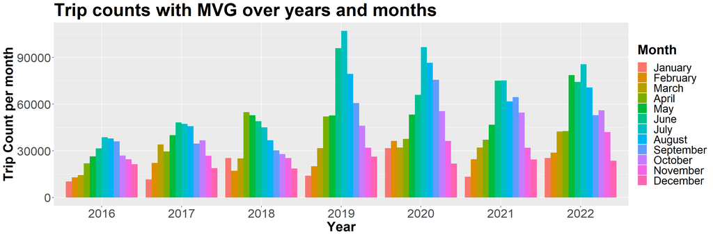

```r
#Bar charts

##COUNTS
trip_counts = group_by(data_every_use,Year,Month)

trip_counts = summarise(trip_counts,
                        counts = length(Row))

#Month names for the bar
trip_counts$Month = month.name[trip_counts$Month]

# Convert Month to factor with custom levels
trip_counts$Month <- factor(trip_counts$Month, levels = c("January", "February", "March", "April", "May", "June", "July", "August", "September", "October", "November", "December"))
trip_counts$Year <- factor(trip_counts$Year, levels = c(2016:2022))

#counts sum
trip_sum = group_by(trip_counts,Year)
trip_sum = summarise(trip_sum,
                     sum(counts))

#charts
ggplot(data=trip_counts, aes(x=Year, y=counts, group=Month, fill = Month)) +
  geom_bar(position='dodge', stat='identity') +
  labs(title = "Trip counts with MVG over years and months",
       y = "Trip Count per month") +
  theme(axis.text=element_text(size=22),
        axis.title=element_text(size=24),
        legend.title = element_text(size=24),
        legend.text = element_text(size=20),
        title = element_text(size=27,face="bold"))
```

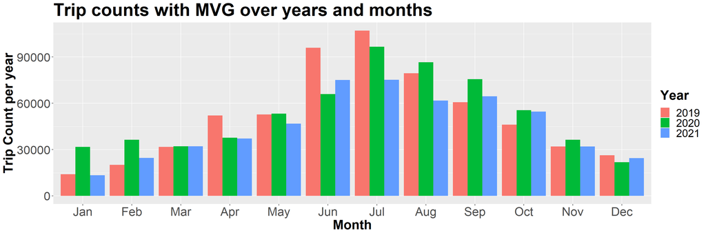

```r
#factors for month abbreviations
trip_counts$Month = month.abb[trip_counts$Month]
trip_counts$Month <- factor(trip_counts$Month, levels = c("Jan", "Feb", "Mar", "Apr", "May", "Jun", "Jul", "Aug", "Sep", "Oct", "Nov", "Dec"))

#factor for pandemic months
trip_counts = filter(trip_counts, Year %in% 2019:2021)
trip_counts$Year <- factor(trip_counts$Year, levels = c(2019:2021))

#Analysis for specific months, comparison
ggplot(data=trip_counts, aes(x=Month, y=counts, group=Year, fill = Year)) +
  geom_bar(position='dodge', stat='identity') +
  labs(title = "Trip counts with MVG over years and months",
       y = "Trip Count per year", x = "Month") +
  theme(axis.text=element_text(size=22),
        axis.title=element_text(size=24),
        legend.title = element_text(size=24),
        legend.text = element_text(size=20),
        title = element_text(size=27,face="bold"))
```

## 4.2 Trip distances’ charts

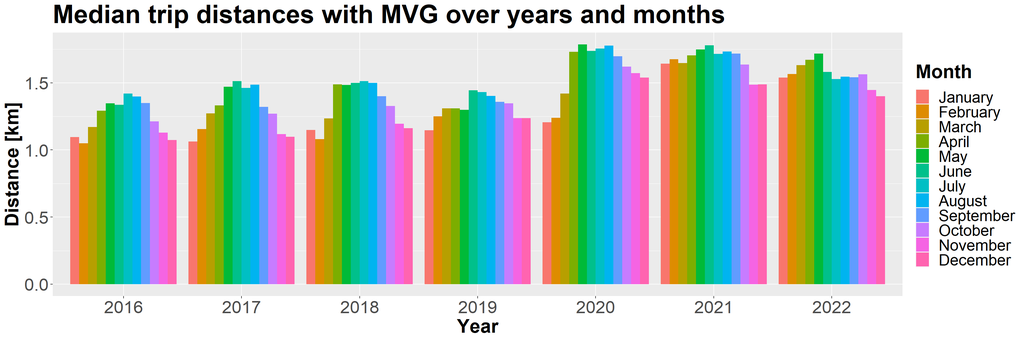

```r
##DISTANCE
dist_counts = group_by(data_every_use,Year,Month)

dist_counts = summarise(dist_counts,
                        distan = median(distance))

#Month names for the bar
dist_counts$Month = month.name[dist_counts$Month]

# Convert Month to factor with custom levels
dist_counts$Month <- factor(dist_counts$Month, levels = c("January", "February", "March", "April", "May", "June", "July", "August", "September", "October", "November", "December"))
dist_counts$Year <- factor(dist_counts$Year, levels = c(2016:2022))

#median distances

dist_med = group_by(data_every_use,Year)
dist_med = summarise(dist_med,
                     median(distance))


#charts
ggplot(data=dist_counts, aes(x=Year, y=distan, group=Month, fill = Month)) +
  geom_bar(position='dodge', stat='identity') +
  labs(title = "Median trip distances with MVG over years and months",
       y = "Distance [km]") +
  theme(axis.text=element_text(size=22),
        axis.title=element_text(size=24),
        legend.title = element_text(size=24),
        legend.text = element_text(size=20),
        title = element_text(size=27,face="bold"))
```

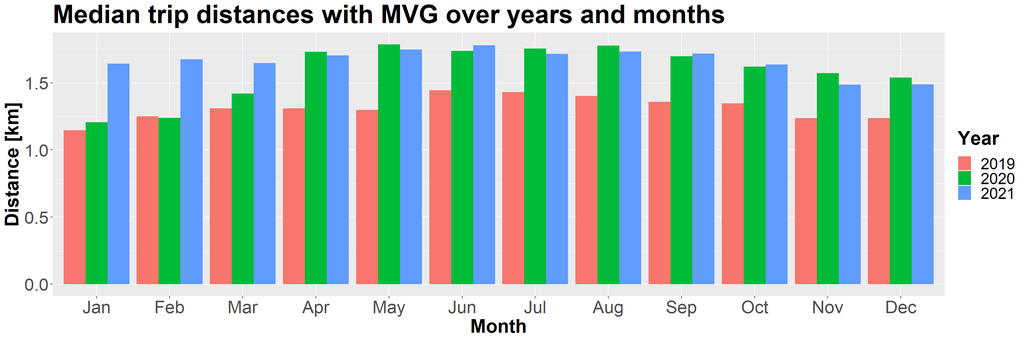

```r
dist_counts$Month = month.abb[dist_counts$Month]
dist_counts$Month <- factor(dist_counts$Month, levels = c("Jan", "Feb", "Mar", "Apr", "May", "Jun", "Jul", "Aug", "Sep", "Oct", "Nov", "Dec"))

dist_counts = filter(dist_counts, Year %in% 2019:2021)
dist_counts$Year <- factor(dist_counts$Year, levels = c(2019:2021))

#Analysis for specific months, comparison
ggplot(data=dist_counts, aes(x=Month, y=distan, group=Year, fill = Year)) +
  geom_bar(position='dodge', stat='identity') +
  labs(title = "Median trip distances with MVG over years and months",
       y = "Distance [km]", x = "Month") +
  theme(axis.text=element_text(size=22),
        axis.title=element_text(size=24),
        legend.title = element_text(size=24),
        legend.text = element_text(size=20),
        title = element_text(size=27,face="bold"))
```

## 4.3 Trip durations’ charts

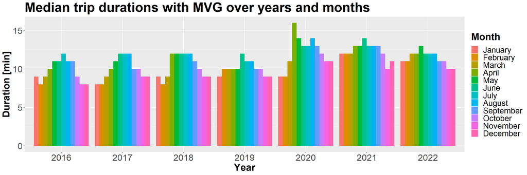

```r
##Duration
dur_counts = group_by(data_every_use,Year,Month)

dur_counts = summarise(dur_counts,
                        dur = median(Duration_minutes))


#Month names for the bar
dur_counts$Month = month.name[dur_counts$Month]

# Convert Month to factor with custom levels
dur_counts$Month <- factor(dur_counts$Month, levels = c("January", "February", "March", "April", "May", "June", "July", "August", "September", "October", "November", "December"))
dur_counts$Year <- factor(dur_counts$Year, levels = c(2016:2022))


#durations for sums
dur_med = group_by(data_every_use,Year)
dur_med = summarise(dur_med,
                     median(Duration_minutes))

#charts
ggplot(data=dur_counts, aes(x=Year, y=dur, group=Month, fill = Month)) +
  geom_bar(position='dodge', stat='identity') +
  labs(title = "Median trip durations with MVG over years and months",
       y = "Duration [min]") +
  theme(axis.text=element_text(size=22),
        axis.title=element_text(size=24),
        legend.title = element_text(size=24),
        legend.text = element_text(size=20),
        title = element_text(size=27,face="bold"))
```

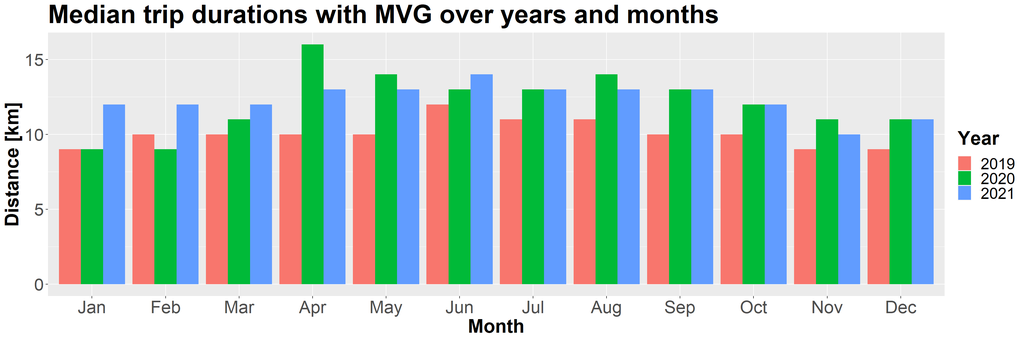

```r
dur_counts$Month = month.abb[dur_counts$Month]
dur_counts$Month <- factor(dur_counts$Month, levels = c("Jan", "Feb", "Mar", "Apr", "May", "Jun", "Jul", "Aug", "Sep", "Oct", "Nov", "Dec"))

dur_counts = filter(dur_counts, Year %in% 2019:2021)
dur_counts$Year <- factor(dur_counts$Year, levels = c(2019:2021))

#Analysis for specific months, comparison
ggplot(data=dur_counts, aes(x=Month, y=dur, group=Year, fill = Year)) +
  geom_bar(position='dodge', stat='identity') +
  labs(title = "Median trip durations with MVG over years and months",
       y = "Distance [km]", x = "Month") +
  theme(axis.text=element_text(size=22),
        axis.title=element_text(size=24),
        legend.title = element_text(size=24),
        legend.text = element_text(size=20),
        title = element_text(size=27,face="bold"))
```

## 4.4 Trips by the time of the day charts

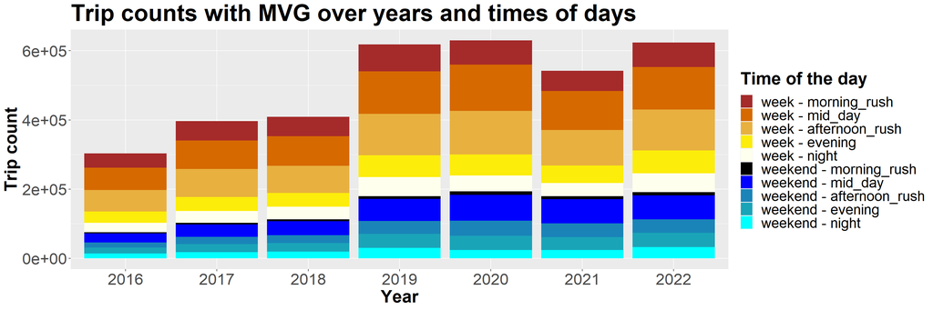

```r
#for groupping something
#night/day distuinguish night is from 22 to 6
data_every_use$day_time = "night"
data_every_use$day_time[data_every_use$hour >= 7 & data_every_use$hour <= 9] = "morning_rush"
data_every_use$day_time[data_every_use$hour > 9 & data_every_use$hour < 16] = "mid_day"
data_every_use$day_time[data_every_use$hour >= 16 & data_every_use$hour <= 18] = "afternoon_rush"
data_every_use$day_time[data_every_use$hour > 18 & data_every_use$hour < 22] = "evening"

data_every_use$Week_Day = wday(data_every_use$Date, FALSE, FALSE, 1)

#weekend/weekday
data_every_use$week_weekend = "week"
data_every_use$week_weekend [data_every_use$Week_Day == 6 | data_every_use$Week_Day == 7] = "weekend"
data_every_use$week_weekend [data_every_use$Week_Day == 5 & data_every_use$day_time == "evening"] = "weekend"

#!!!!!!!!!!!!!!!!!!!!!!!!!!!!!!!!!!!!!!!!!!#
#for groupping, by times of the day and years

data_every_use$group_times = paste(data_every_use$week_weekend, "-",data_every_use$day_time)

data_bytimes_years = group_by(data_every_use, Year, group_times)

data_bytimes_years = summarise(data_bytimes_years,
                               counts = length(Row),
                               dur = median(Duration_minutes),
                               distan = median(distance))

data_bytimes_years$Year <- factor(data_bytimes_years$Year, levels = c(2016,2017,2018,2019,2020,2021,2022))
data_bytimes_years$group_times <- factor(data_bytimes_years$group_times, levels = c('week - morning_rush','week - mid_day','week - afternoon_rush','week - evening','week - night',
                                                                      'weekend - morning_rush','weekend - mid_day', 'weekend - afternoon_rush', 'weekend - evening', 'weekend - night'))
#charts, times of days, years and trip counts
ggplot(data=data_bytimes_years, aes(x=Year, y=counts, group=group_times, fill = group_times)) +
  geom_bar(position="stack", stat='identity') +
  labs(title = "Trip counts with MVG over years and times of days",
       y = "Trip count", fill = "Time of the day") +
  theme(axis.text=element_text(size=22),
        axis.title=element_text(size=24),
        legend.title = element_text(size=24),
        legend.text = element_text(size=20),
        title = element_text(size=27,face="bold")) +
  scale_fill_manual(values = c("brown","#D66900", "#E8B03F", "#FCED0A", "#FFFFED",
                                 "black","blue","#1a84b8","#1aa4b8", "cyan"))
```

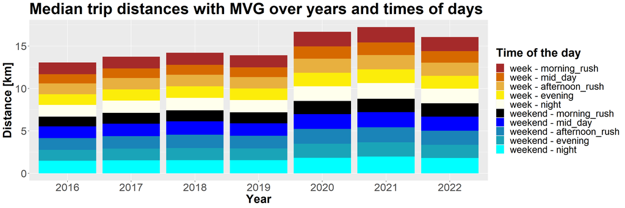

```r
#charts, times of days, years and trip distances
ggplot(data=data_bytimes_years, aes(x=Year, y=distan, group=group_times, fill = group_times)) +
  geom_bar(position="stack", stat='identity') +
  labs(title = "Median trip distances with MVG over years and times of days",
       y = "Distance [km]", fill = "Time of the day") +
  theme(axis.text=element_text(size=22),
        axis.title=element_text(size=24),
        legend.title = element_text(size=24),
        legend.text = element_text(size=20),
        title = element_text(size=27,face="bold")) + scale_y_continuous(labels = scales::comma)+
  scale_fill_manual(values = c("brown","#D66900", "#E8B03F", "#FCED0A", "#FFFFED",
                               "black","blue","#1a84b8","#1aa4b8", "cyan"))
```

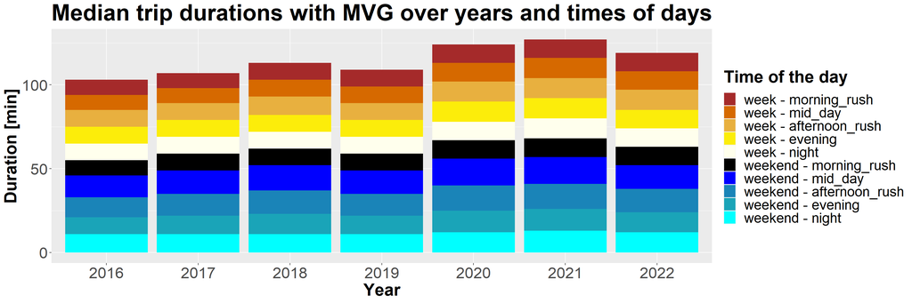

```r
#charts, times of days, years and trip duration
ggplot(data=data_bytimes_years, aes(x=Year, y=dur, group=group_times, fill = group_times)) +
  geom_bar(position="stack", stat='identity') +
  labs(title = "Median trip durations with MVG over years and times of days",
       y = "Duration [min]", fill = "Time of the day") +
  theme(axis.text=element_text(size=22),
        axis.title=element_text(size=24),
        legend.title = element_text(size=24),
        legend.text = element_text(size=20),
        title = element_text(size=27,face="bold")) + scale_y_continuous(labels = scales::comma)+
  scale_fill_manual(values = c("brown","#D66900", "#E8B03F", "#FCED0A", "#FFFFED",
                               "black","blue","#1a84b8","#1aa4b8", "cyan"))
```

## 4.5 Trips between specific landuses table

```r
#some tables for trips between specific landuse types

#making a string to display
data_every_use$from_to = paste(data_every_use$landuse_start, "-",data_every_use$landuse_end)

travels_year_month = group_by(data_every_use, from_to,Year)

travels_year_month = summarise(travels_year_month,
                               counts = length(Row))

travels_year_month = arrange(travels_year_month, desc(counts))

travels_year_month = filter(travels_year_month, Year %in% 2019:2021)


filter(travels_year_month, Year == 2019) %>%
  kbl(caption = "Trips between specific landuse types in 2019") %>%
  kable_minimal()
```

Trips between specific landuse types in 2019

| from_to | Year | counts |
| --- | --- | --- |
| mixed-use - mixed-use | 2019 | 157302 |
| mixed-use - residential | 2019 | 48220 |
| university - mixed-use | 2019 | 44883 |
| residential - mixed-use | 2019 | 44436 |
| mixed-use - university | 2019 | 43776 |
| residential - residential | 2019 | 42221 |
| university - university | 2019 | 25874 |
| recreational - mixed-use | 2019 | 25816 |
| mixed-use - recreational | 2019 | 25224 |
| recreational - recreational | 2019 | 14063 |
| commercial - mixed-use | 2019 | 12690 |
| mixed-use - commercial | 2019 | 12503 |
| residential - recreational | 2019 | 12288 |
| recreational - residential | 2019 | 12160 |
| residential - university | 2019 | 8877 |
| university - residential | 2019 | 8576 |
| commercial - residential | 2019 | 8312 |
| residential - commercial | 2019 | 8170 |
| commercial - commercial | 2019 | 6618 |
| university - recreational | 2019 | 6570 |
| recreational - university | 2019 | 6399 |
| industrial - mixed-use | 2019 | 6196 |
| mixed-use - industrial | 2019 | 6122 |
| commercial - recreational | 2019 | 4524 |
| recreational - commercial | 2019 | 4270 |
| residential - industrial | 2019 | 3609 |
| industrial - residential | 2019 | 3485 |
| university - commercial | 2019 | 2241 |
| commercial - university | 2019 | 2239 |
| industrial - industrial | 2019 | 1826 |
| recreational - industrial | 2019 | 1437 |
| industrial - recreational | 2019 | 1392 |
| industrial - commercial | 2019 | 1290 |
| commercial - industrial | 2019 | 1211 |
| industrial - university | 2019 | 970 |
| university - industrial | 2019 | 914 |
| residential - farmland | 2019 | 356 |
| farmland - residential | 2019 | 347 |
| mixed-use - farmland | 2019 | 280 |
| farmland - mixed-use | 2019 | 237 |
| farmland - farmland | 2019 | 57 |
| commercial - farmland | 2019 | 51 |
| farmland - commercial | 2019 | 50 |
| farmland - recreational | 2019 | 44 |
| recreational - farmland | 2019 | 42 |
| farmland - industrial | 2019 | 35 |
| industrial - farmland | 2019 | 35 |
| university - farmland | 2019 | 21 |
| farmland - university | 2019 | 17 |
| NA - residential | 2019 | 1 |
| recreational - NA | 2019 | 1 |

```r
filter(travels_year_month, Year == 2020) %>%
  kbl(caption = "Trips between specific landuse types in 2020") %>%
  kable_minimal()
```

Trips between specific landuse types in 2020

| from_to | Year | counts |
| --- | --- | --- |
| mixed-use - mixed-use | 2020 | 169005 |
| mixed-use - residential | 2020 | 51305 |
| residential - mixed-use | 2020 | 48909 |
| university - mixed-use | 2020 | 44772 |
| mixed-use - university | 2020 | 43980 |
| residential - residential | 2020 | 42544 |
| recreational - mixed-use | 2020 | 28729 |
| mixed-use - recreational | 2020 | 28301 |
| university - university | 2020 | 20323 |
| residential - recreational | 2020 | 12995 |
| recreational - residential | 2020 | 12774 |
| recreational - recreational | 2020 | 12249 |
| commercial - mixed-use | 2020 | 10996 |
| mixed-use - commercial | 2020 | 10830 |
| residential - university | 2020 | 9912 |
| university - residential | 2020 | 9707 |
| commercial - residential | 2020 | 7211 |
| residential - commercial | 2020 | 6996 |
| mixed-use - industrial | 2020 | 6784 |
| university - recreational | 2020 | 6631 |
| industrial - mixed-use | 2020 | 6468 |
| recreational - university | 2020 | 6451 |
| commercial - commercial | 2020 | 4207 |
| industrial - residential | 2020 | 3624 |
| residential - industrial | 2020 | 3560 |
| commercial - recreational | 2020 | 3141 |
| recreational - commercial | 2020 | 2977 |
| university - commercial | 2020 | 2176 |
| commercial - university | 2020 | 2015 |
| industrial - industrial | 2020 | 1539 |
| recreational - industrial | 2020 | 1351 |
| industrial - recreational | 2020 | 1297 |
| university - industrial | 2020 | 997 |
| commercial - industrial | 2020 | 969 |
| industrial - commercial | 2020 | 964 |
| industrial - university | 2020 | 920 |
| residential - farmland | 2020 | 451 |
| farmland - residential | 2020 | 438 |
| mixed-use - farmland | 2020 | 334 |
| farmland - mixed-use | 2020 | 292 |
| farmland - farmland | 2020 | 84 |
| recreational - farmland | 2020 | 84 |
| farmland - recreational | 2020 | 67 |
| commercial - farmland | 2020 | 66 |
| farmland - commercial | 2020 | 56 |
| farmland - industrial | 2020 | 42 |
| industrial - farmland | 2020 | 41 |
| farmland - university | 2020 | 23 |
| university - farmland | 2020 | 22 |
| residential - NA | 2020 | 7 |
| NA - industrial | 2020 | 4 |
| NA - residential | 2020 | 3 |
| NA - mixed-use | 2020 | 1 |
| NA - university | 2020 | 1 |
| mixed-use - NA | 2020 | 1 |
| recreational - NA | 2020 | 1 |

```r
filter(travels_year_month, Year == 2021) %>%
  kbl(caption = "Trips between specific landuse types in 2021") %>%
  kable_minimal()
```

Trips between specific landuse types in 2021

| from_to | Year | counts |
| --- | --- | --- |
| mixed-use - mixed-use | 2021 | 159611 |
| university - mixed-use | 2021 | 41687 |
| mixed-use - residential | 2021 | 41607 |
| mixed-use - university | 2021 | 40170 |
| residential - mixed-use | 2021 | 39373 |
| residential - residential | 2021 | 27765 |
| recreational - mixed-use | 2021 | 25691 |
| mixed-use - recreational | 2021 | 25340 |
| university - university | 2021 | 18210 |
| recreational - recreational | 2021 | 11597 |
| recreational - residential | 2021 | 9700 |
| residential - recreational | 2021 | 9612 |
| mixed-use - commercial | 2021 | 9302 |
| commercial - mixed-use | 2021 | 9159 |
| residential - university | 2021 | 8685 |
| university - residential | 2021 | 8425 |
| university - recreational | 2021 | 5901 |
| recreational - university | 2021 | 5806 |
| mixed-use - industrial | 2021 | 5777 |
| industrial - mixed-use | 2021 | 5611 |
| commercial - residential | 2021 | 4819 |
| residential - commercial | 2021 | 4600 |
| residential - industrial | 2021 | 2743 |
| commercial - commercial | 2021 | 2733 |
| industrial - residential | 2021 | 2635 |
| commercial - recreational | 2021 | 2331 |
| recreational - commercial | 2021 | 2263 |
| university - commercial | 2021 | 1732 |
| commercial - university | 2021 | 1624 |
| industrial - industrial | 2021 | 1259 |
| recreational - industrial | 2021 | 1097 |
| industrial - recreational | 2021 | 980 |
| university - industrial | 2021 | 927 |
| industrial - university | 2021 | 892 |
| commercial - industrial | 2021 | 694 |
| industrial - commercial | 2021 | 606 |
| farmland - residential | 2021 | 122 |
| mixed-use - farmland | 2021 | 120 |
| residential - farmland | 2021 | 119 |
| farmland - mixed-use | 2021 | 84 |
| commercial - farmland | 2021 | 39 |
| farmland - farmland | 2021 | 28 |
| farmland - recreational | 2021 | 22 |
| farmland - commercial | 2021 | 21 |
| recreational - farmland | 2021 | 20 |
| university - farmland | 2021 | 18 |
| industrial - farmland | 2021 | 14 |
| farmland - industrial | 2021 | 13 |
| farmland - university | 2021 | 11 |
| NA - residential | 2021 | 1 |